# week 5: integers and other monsters

counts

```r
library(tidyverse)
library(psych)
library(cowplot)
library(patchwork)
library(here)
library(brms)
library(tidybayes)
```

## populations and tools

```r
library(ggdag)
```

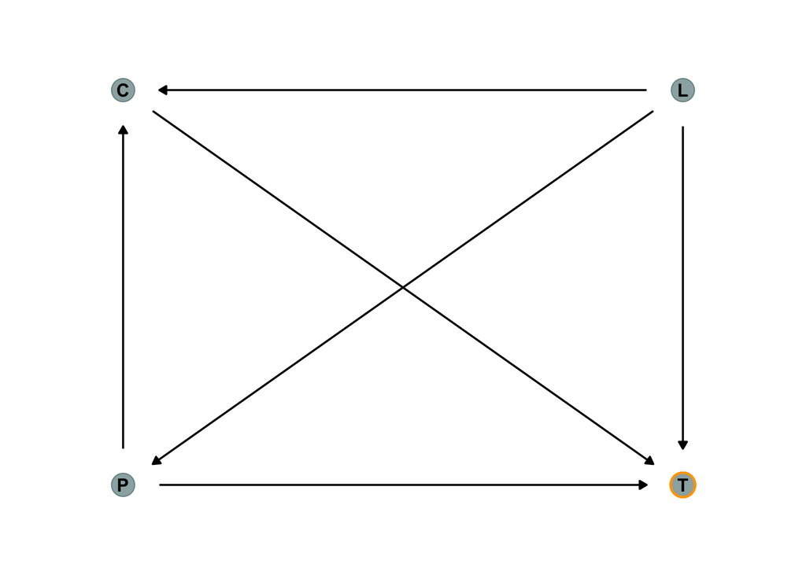

```r
dag_coords <-
  tibble(name = c("C", "P", "L", "T"),
         x    = c(1, 1, 2, 2),
         y    = c(2, 1, 2, 1))

dagify(C ~ L + P,
       P ~ L,
       T ~ C + L + P,
       coords = dag_coords) %>%

  ggplot(aes(x = x, y = y, xend = xend, yend = yend)) +
  geom_dag_point(aes(color = name == "D"),
                 alpha = 1/2, size = 6.5, show.legend = F) +
  geom_point(x = 2, y = 1,
             size = 6.5, shape = 1, stroke = 1, color = "orange") +
  geom_dag_text(color = "black") +
  geom_dag_edges() +
  scale_color_manual(values = c("#1c5253", "orange")) +
  scale_x_continuous(NULL, breaks = NULL, expand = c(.1, .1)) +
  scale_y_continuous(NULL, breaks = NULL, expand = c(.1, .1))
```

### counts are poisson distributed

$$\begin{align*}
Y_i &\sim \text{Poisson}(\lambda_i) \\
\text{log}(\lambda_i) &= \alpha + \beta x_i \\
\lambda_i &= \text{exp}(\alpha + \beta x_i)
\end{align*}$$

You’ll need to be careful about your priors.

$$\begin{align*}
\text{log}(\lambda_i) &= \alpha \\
\alpha &\sim \text{Normal}(0,10)
\end{align*}$$

Simulate this:

```r
n_sim = 1e4
alpha_prior = rnorm(n_sim, 0, 10)
lambda_prior = exp(alpha_prior)
count_prior = rpois(n_sim, lambda_prior)
range(count_prior)
```

```
## [1] 0.000000e+00 1.348131e+16
```

```r
mean(count_prior)
```

```
## [1] 2.208852e+12
```

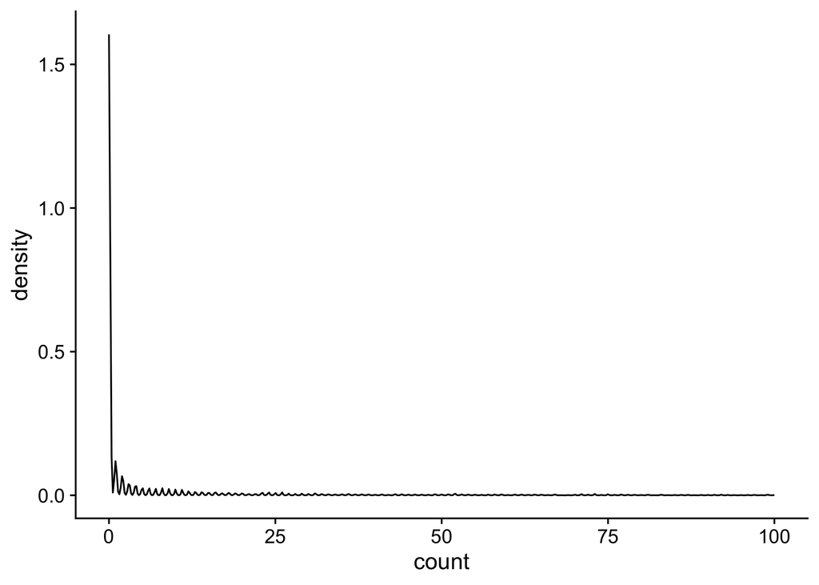

```r
data.frame(count = count_prior) %>%
  ggplot(aes(x = count)) +
  geom_density() +
  scale_x_continuous(limits = c(0, 100))
```

$$\begin{align*}
\text{log}(\lambda_i) &= \alpha \\
\alpha &\sim \text{Normal}(3,.5)
\end{align*}$$

Simulate this:

```r
n_sim = 1e4
alpha_prior = rnorm(n_sim, 3, .5)
lambda_prior = exp(alpha_prior)
count_prior = rpois(n_sim, lambda_prior)
range(count_prior)
```

```
## [1]   0 113
```

```r
mean(count_prior)
```

```
## [1] 22.5546
```

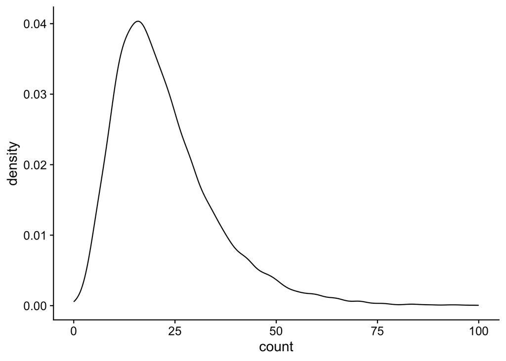

```r
data.frame(count = count_prior) %>%
  ggplot(aes(x = count)) +
  geom_density() +
  scale_x_continuous(limits = c(0, 100))
```

## example

```r
data(Kline, package = "rethinking")
Kline <- Kline
Kline
```

```
##       culture population contact total_tools mean_TU
## 1    Malekula       1100     low          13     3.2
## 2     Tikopia       1500     low          22     4.7
## 3  Santa Cruz       3600     low          24     4.0
## 4         Yap       4791    high          43     5.0
## 5    Lau Fiji       7400    high          33     5.0
## 6   Trobriand       8000    high          19     4.0
## 7       Chuuk       9200    high          40     3.8
## 8       Manus      13000     low          28     6.6
## 9       Tonga      17500    high          55     5.4
## 10     Hawaii     275000     low          71     6.6
```

```r
Kline = Kline %>%
  mutate(
    P = log(population),
    contact_id = ifelse( contact == "high", 2, 1)
  )
```

Intercept only model

```r
m1 <- brm(
  data = Kline,
  family = poisson,
  total_tools ~ 1,
  prior = c( prior( normal(3, 0.5), class = Intercept) ),
  iter = 2000, warmup = 1000, chains = 4, cores = 4,
  seed = 11,
  file = here("files/data/generated_data/m52.1")
)
```

```r
Kline = Kline %>%
  mutate(
    P = log(population),
    contact_id = ifelse( contact == "high", 2, 1)
  )
```

Interaction model

```r
m2 <- brm(
  data = Kline,
  family = poisson,
  bf(total_tools ~ a + b*P,
     a + b ~ 0 + contact,
     nl = TRUE),
  prior = c( prior( normal(3, 0.5), nlpar = a),
             prior( normal(0, 0.2), nlpar = b)),
  iter = 2000, warmup = 1000, chains = 4, cores = 4,
  seed = 11,
  file = here("files/data/generated_data/m52.2")
)
```

```r
m1
```

```
##  Family: poisson
##   Links: mu = log
## Formula: total_tools ~ 1
##    Data: Kline (Number of observations: 10)
##   Draws: 4 chains, each with iter = 2000; warmup = 1000; thin = 1;
##          total post-warmup draws = 4000
##
## Regression Coefficients:
##           Estimate Est.Error l-95% CI u-95% CI Rhat Bulk_ESS Tail_ESS
## Intercept     3.54      0.05     3.44     3.64 1.00     1716     1970
##
## Draws were sampled using sampling(NUTS). For each parameter, Bulk_ESS
## and Tail_ESS are effective sample size measures, and Rhat is the potential
## scale reduction factor on split chains (at convergence, Rhat = 1).
```

```r
m2
```

```
##  Family: poisson
##   Links: mu = log
## Formula: total_tools ~ a + b * P
##          a ~ 0 + contact
##          b ~ 0 + contact
##    Data: Kline (Number of observations: 10)
##   Draws: 4 chains, each with iter = 2000; warmup = 1000; thin = 1;
##          total post-warmup draws = 4000
##
## Regression Coefficients:
##               Estimate Est.Error l-95% CI u-95% CI Rhat Bulk_ESS Tail_ESS
## a_contacthigh     2.84      0.47     1.92     3.74 1.00     1378     1405
## a_contactlow      1.69      0.29     1.13     2.25 1.00     1439     1323
## b_contacthigh     0.09      0.05    -0.01     0.19 1.00     1399     1489
## b_contactlow      0.19      0.03     0.14     0.25 1.00     1444     1295
##
## Draws were sampled using sampling(NUTS). For each parameter, Bulk_ESS
## and Tail_ESS are effective sample size measures, and Rhat is the potential
## scale reduction factor on split chains (at convergence, Rhat = 1).
```

### What do these mean?

Once we’ve moved outside of the Gaussian distribution, your best bet is to push everything back through the posterior. Do NOT try and evaluate the model estimates.

```r
nd <- data.frame(P = 1) # intercept only model

epred_draws(object = m1, newdata = nd) %>%
  median_qi
```

```
## # A tibble: 1 × 8
##       P  .row .epred .lower .upper .width .point .interval
##   <dbl> <int>  <dbl>  <dbl>  <dbl>  <dbl> <chr>  <chr>
## 1     1     1   34.6   31.1   38.2   0.95 median qi
```

```r
nd <-
  distinct(Kline, contact) %>%
  expand_grid(P = seq(from = min(Kline$P),
                            to=max(Kline$P),
                            length.out = 100))

f2 <- epred_draws(object = m2, newdata = nd) %>%
  group_by(contact, P) %>%
  median_qi

f2
```

```
## # A tibble: 200 × 8
##    contact     P .epred .lower .upper .width .point .interval
##    <fct>   <dbl>  <dbl>  <dbl>  <dbl>  <dbl> <chr>  <chr>
##  1 high     7.00   31.7   24.9   40.2   0.95 median qi
##  2 high     7.06   31.9   25.1   40.3   0.95 median qi
##  3 high     7.11   32.0   25.4   40.3   0.95 median qi
##  4 high     7.17   32.2   25.6   40.3   0.95 median qi
##  5 high     7.23   32.4   25.8   40.3   0.95 median qi
##  6 high     7.28   32.5   26.1   40.4   0.95 median qi
##  7 high     7.34   32.7   26.3   40.4   0.95 median qi
##  8 high     7.39   32.8   26.6   40.4   0.95 median qi
##  9 high     7.45   33.0   26.9   40.5   0.95 median qi
## 10 high     7.51   33.2   27.1   40.5   0.95 median qi
## # ℹ 190 more rows
```

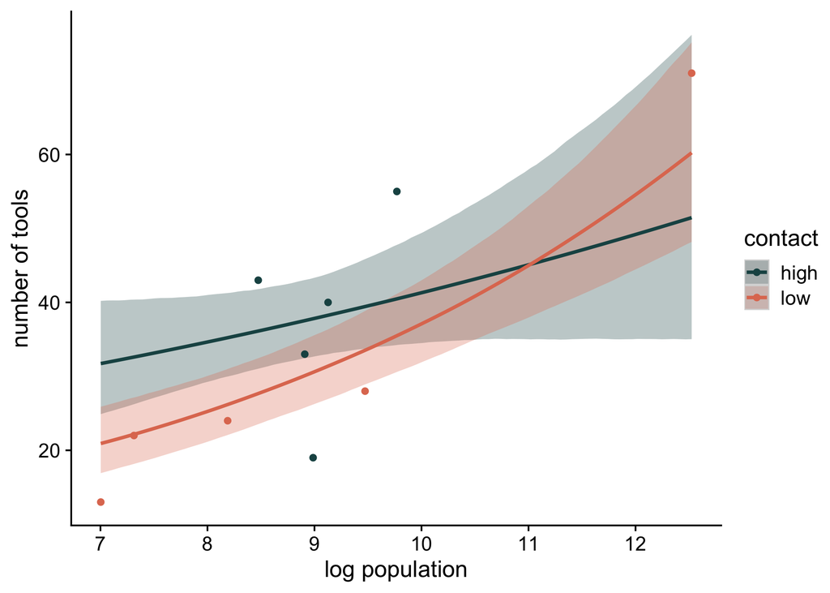

```r
f2 %>%
  ggplot(aes(x = P)) +
  geom_ribbon(aes(ymin = .lower, ymax = .upper, fill = contact),
              alpha = .3) +
  geom_smooth(aes(y = .epred, color = contact)) +
  geom_point(data = Kline, aes(y = total_tools, color = contact)) +
  labs(x = "log population", y = "number of tools")
```

## compare

```r
m1  <- add_criterion(m1, "loo")
m2 <- add_criterion(m2, "loo")

loo_compare(m1, m2, criterion = "loo") %>% print(simplify = F)
```

```
##    elpd_diff se_diff elpd_loo se_elpd_loo p_loo se_p_loo looic se_looic
## m2   0.0       0.0   -45.7      7.2         8.2   3.4     91.3  14.3
## m1 -24.9      14.0   -70.6     16.9         7.9   3.5    141.2  33.7
```

```r
loo(m2) %>% loo::pareto_k_table()
```

```
## Pareto k diagnostic values:
##                          Count Pct.    Min. ESS
## (-Inf, 0.7]   (good)     9     90.0%   232
##    (0.7, 1]   (bad)      0      0.0%   <NA>
##    (1, Inf)   (very bad) 1     10.0%   <NA>
```

```r
m2k = m2$criteria$loo$pointwise %>%
  as.data.frame() %>%
  mutate(culture = Kline$culture) %>%
  arrange(desc(influence_pareto_k)) %>%
  mutate_if(is.double, round, digits = 2)
m2k
```

```
##    elpd_loo mcse_elpd_loo p_loo looic influence_pareto_k    culture
## 1     -7.12          0.49  3.27 14.24               1.27     Hawaii
## 2     -6.44          0.06  1.60 12.87               0.56      Tonga
## 3     -9.23          0.05  1.82 18.45               0.43  Trobriand
## 4     -3.28          0.01  0.20  6.56               0.29      Manus
## 5     -4.51          0.04  0.77  9.02               0.29   Malekula
## 6     -3.71          0.02  0.30  7.42               0.26        Yap
## 7     -3.12          0.01  0.12  6.23               0.23   Lau Fiji
## 8     -2.74          0.01  0.06  5.47               0.17 Santa Cruz
## 9     -2.93          0.01  0.04  5.86               0.16      Chuuk
## 10    -2.59          0.00  0.03  5.19               0.13    Tikopia
```

Adding these to our plot:

```r
m2k = m2k %>% full_join(Kline)
```

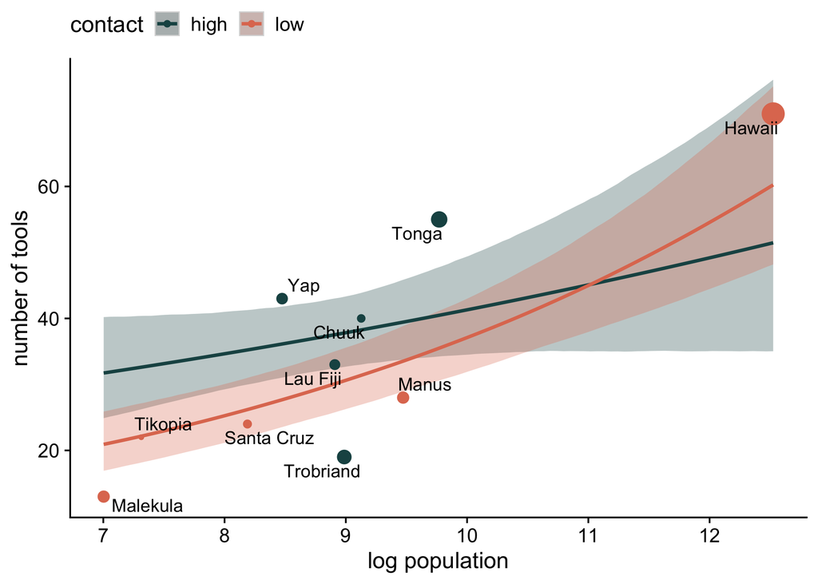

```r
library(ggrepel)
f2 %>%
  ggplot(aes(x = P)) +
  geom_ribbon(aes(ymin = .lower, ymax = .upper, fill = contact),
              alpha = .3) +
  geom_smooth(aes(y = .epred, color = contact)) +
  geom_point(data = m2k,
             aes(y = total_tools,
                 size = influence_pareto_k,
                 color = contact)) +
  geom_text_repel(data = m2k,
             aes(y = total_tools,
                 label = culture)) +
  guides(size = "none") +
  labs(x = "log population", y = "number of tools") +
  theme(legend.position = "top")
```

Natural scale

```r
m2k = m2k %>% full_join(Kline)
```

[output not shown]

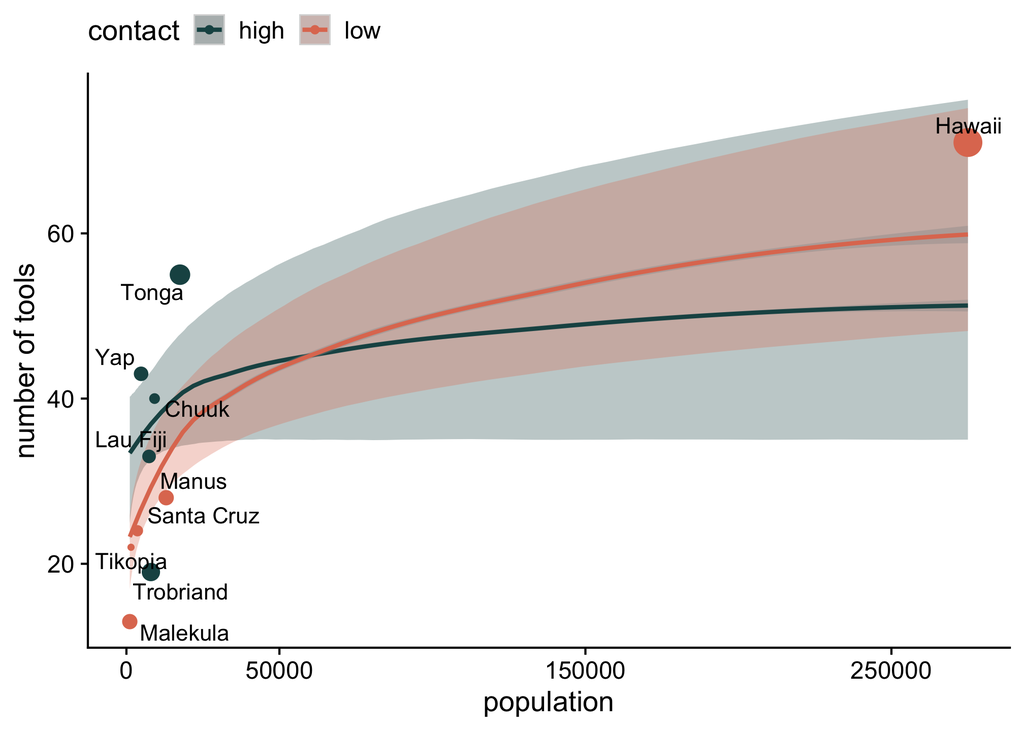

```r
library(ggrepel)
f2 %>%
  ggplot(aes(x = P)) +
  geom_ribbon(aes(ymin = .lower, ymax = .upper, fill = contact),
              alpha = .3) +
  geom_smooth(aes(y = .epred, color = contact)) +
  geom_point(data = m2k,
             aes(y = total_tools,
                 size = influence_pareto_k,
                 color = contact)) +
  geom_text_repel(data = m2k,
             aes(y = total_tools,
                 label = culture)) +
  scale_x_continuous(trans = "exp",
                     breaks = log(c(0, 50000, 150000, 250000)),
                     labels = c(0, 50000, 150000, 250000)) +
  guides(size = "none") +
  labs(x = "population", y = "number of tools") +
  theme(legend.position = "top")
```

## exercise

The data in `data(Primates301)` are 301 primate species and associated measures. Model the number of observations of social_learning for each species as a function of the log brain size. Use a Poisson distribution for the `social_learning` outcome variable. Interpret the resulting posterior.

### solution

```r
data(Primates301, package = "rethinking")
d <- Primates301
d$B <- log(d$brain)

m4 <- brm(
  data = d,
  family = poisson,
  social_learning ~ 1 + B,
  prior = c( prior( normal(3,.5), class = Intercept),
             prior( normal(0, .1), class = b)),
  iter = 2000, warmup = 1000, chains = 4, cores = 4,
  seed = 11,
  file = here("files/data/generated_data/m52.4")
)
```

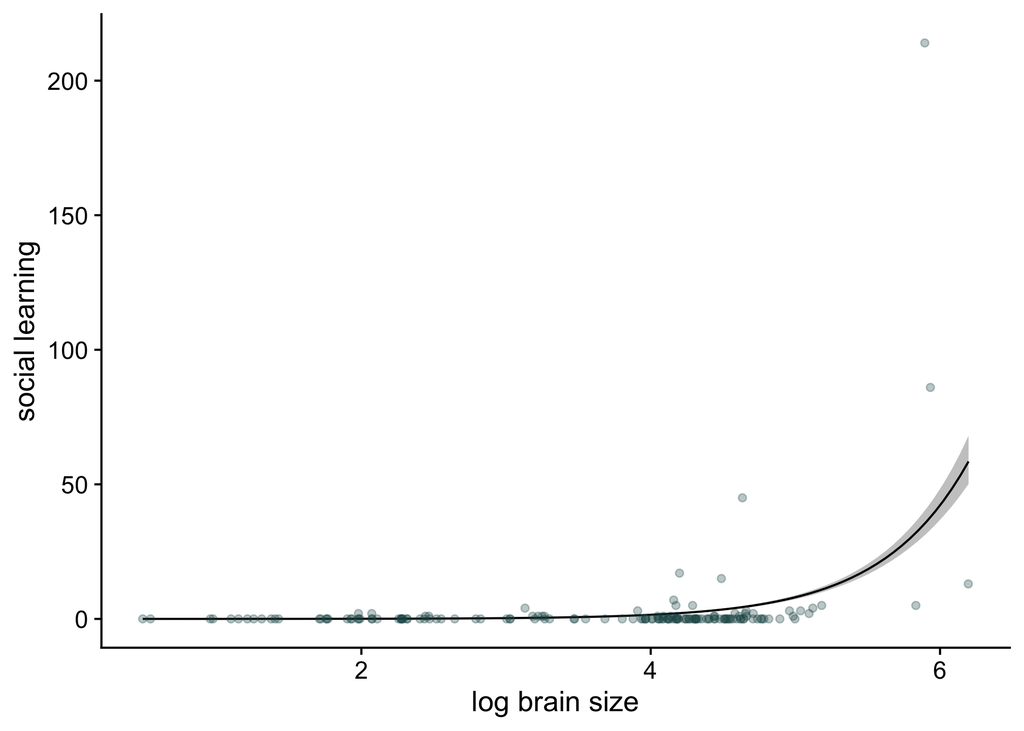

```r
nd <- expand.grid(
  B = seq(min(d$B, na.rm=T), max(d$B, na.rm=T), length = 100)
)

f4 <- epred_draws(m4, nd) %>%
  with_groups(B, median_qi, .epred)

ggplot(f4, aes(x = B, y = .epred)) +
  geom_ribbon(aes(ymin = .lower, ymax =.upper), alpha = .3) +
  geom_line() +
  geom_point(data = d,
             aes(y = social_learning),
             alpha = .3,
             color = "#1c5253") +
  labs(x = "log brain size",
       y = "social learning")
```

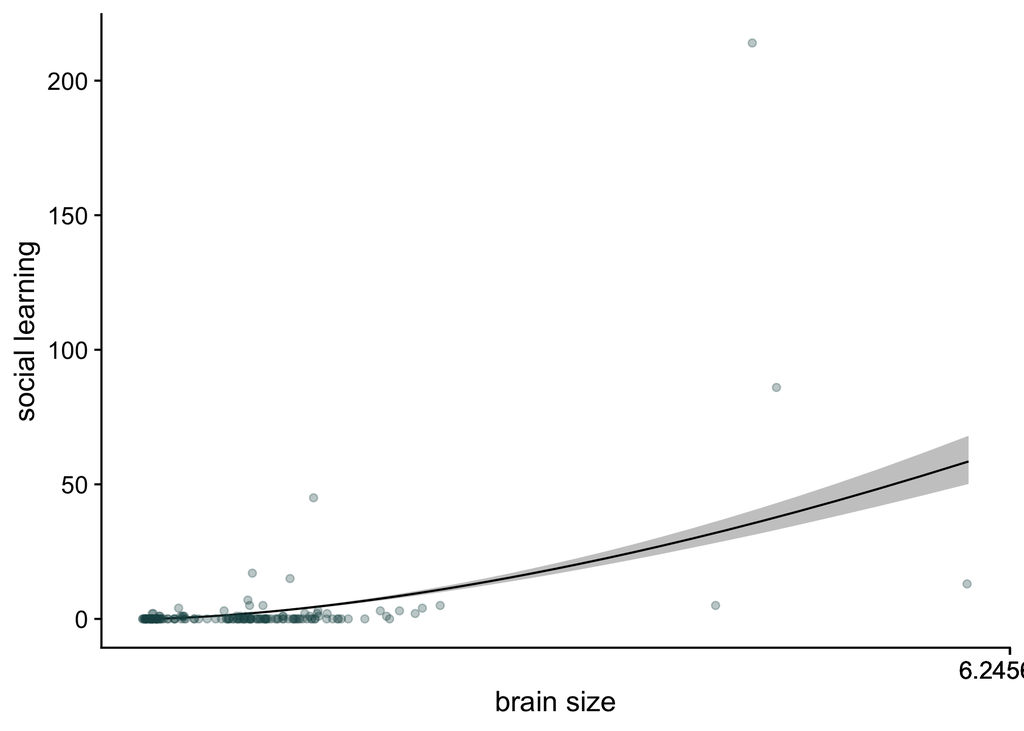

```r
ggplot(f4, aes(x = B, y = .epred)) +
  geom_ribbon(aes(ymin = .lower, ymax =.upper), alpha = .3) +
  geom_line() +
  geom_point(data = d,
             aes(y = social_learning),
             alpha = .3,
             color = "#1c5253") +
  scale_x_continuous(trans = "exp") +
  labs(x = "brain size",
       y = "social learning")
```

Returning to the tools example, McElreath points to a theoretical issue with the plots. He proposes to solve this with a better representation of the relationship between tools and time.

$$\Delta T = \alpha P^{\beta}-\gamma T$$

- $\Delta$ = change
- $\alpha$ = innovation rate
- $\beta$ = diminishing returns (elasticity)
- $\gamma$ = rate of loss

In this case, both $\alpha$ and $\beta$ are moderated by contact.

If you solve for T:

$$\hat{T} = \frac{\alpha_CP^{\beta_C}}{\gamma}$$

Note that in this case we’re **not** using the log link function. Wild! This is because all our parameters must be positive. There are two ways to do this: the first is to use appropriate priors that constrain the parameters. This is nice for transparency, but computationally more difficult. The other option is to use the exponential function (see on `a`). This code does both.

```r
m3 <-
  brm(data = Kline,
      family = poisson(link = "identity"),
      bf(total_tools ~ exp(a) * P^b / g,
         a + b ~ 0 + contact,
         g ~ 1,
         nl = TRUE),
      prior = c(prior(normal(1, 1), nlpar = a),
                prior(exponential(1), nlpar = b, lb = 0),
                prior(exponential(1), nlpar = g, lb = 0)),
      iter = 2000, warmup = 1000, chains = 4, cores = 4,
      seed = 11,
      control = list(adapt_delta = .85),
      file = here("files/data/generated_data/m52.3"))
```

### exercise

Returning to the primate example: Some species are studied much more than others. So the number of reported instances of social_learning could be a product of research effort. Use the research_effort variable, specifically its logarithm, as an additional predictor variable. Interpret the coefficient for log research_effort. How does this model differ from the previous one?